# Applied Economic Forecasting

Introduction to R Markdown

# 1 R Markdown

## 1.1 Introduction

### 1.1.1 What is R Markdown?

According to RStudio,

“R Markdown is a format that enables easy authoring of reproducible web reports from R. It combines the core syntax of Markdown (an easy-to-write plain text format for web content) with embedded R code chunks that are run so their output can be included in the final document”.

[figure not shown]

You can watch the video explaining in more detail what it is [here](https://R%20Markdown.rstudio.com/lesson-1.html)

### 1.1.2 Why is R Markdown useful?

**Traditional way**: Save your code results, tables, and graphs from any statistical software then copy and paste them into your report.

**Why is this not good?**

- Imagine that your client tell you that they do not want full-sample analysis, instead, they want a sub-sample analysis. Because your report is not dynamic, you have to re-do everything and comb through the whole report to make sure that everything is updated!
- I am unable to understand, from your report, how you came to certain numbers and conclusions.
1. R Markdown is **dynamic**.
2. Results are **reproducible** with R Markdown. Everyone having your report could see the results as well as the code producing them. R Markdown support dozens of output formats, like PDFs, Word files, HTML, slideshows, and more.

The idea should be simple enough:

1. interweave narratives with code in a document,
2. knit the document to dynamically generate results from the code,
3. and you will get a report.

### 1.1.3 Where has R Markdown been used?

[Xie et al. 2018 R Markdown: The Definitive Guide](https://bookdown.org/yihui/R%20Markdown/):

Due to the simplicity of Markdown and the powerful R language for data analysis, R Markdown has been widely used in many areas. <https://bookdown.org/yihui/R Markdown/basics-examples.html>

1. Airbnb’s knowledge repository
2. 2017 Employer Health Benefits Survey
3. Journal articles
4. **All my slides & syllabi!**
5. **Your Assignments**
6. Blogs
7. Websites
8. etc…

As you use R Markdown, keep these resources close to hand:

- R Markdown Cheat Sheet: Help >> Cheatsheets >> R Markdown Cheat Sheet,
- R Markdown Reference Guide: Help >> Cheatsheets >> R Markdown Reference Guide.

## 1.2 Creating a New R Markdown file

- Go to File –> New File –> R Markdown to open a new R markdown window.

[figure not shown]

- Choose the file type as a pdf (You could always change this later if this isn’t the file type you would like it to be rendered to).

## 1.3 Document Structure

R Markdown combines normal text, such as this sentence, code and the output from the code all in one file (`.Rmd`).

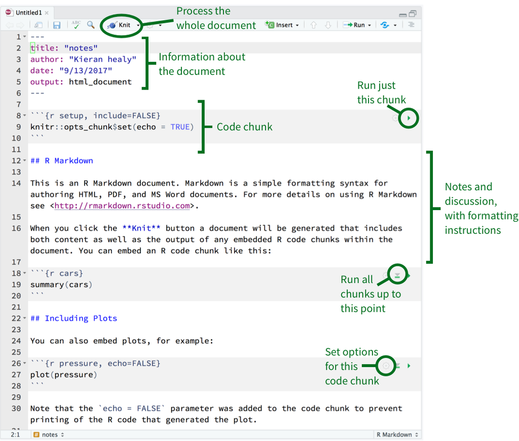

Image credit: Data Visualization by Kieran Healy. Available at http://socviz.co/

You will observe that there are three (3) important aspects to this document:

1. An (optional) YAML header surrounded by `---`s.
2. Chunks of R code surrounded by `` r ``` ``.
3. Text mixed with simple text formatting like `# heading`, `_italics_`, `*italics*`, `**bold**`, `***bold and italics***`.

### 1.3.1 Code Chunks

Code chunks start with three back ticks and an `r` in braces ( `` ```{r}``` `` )

The `r` indicated to R Markdown that you are performing an operation written in the `R` language. We could do the same for python language, css, etc.

Chunks end with another three back ticks ( `` ``` `` )

Note the background color of this section has changed to a different shade. This helps you identify you have closed your code chunk properly.

Aside from manually, you can insert code chunks two way:

1. using the button in the top right of an RMD file (Insert –> R), or

[figure not shown]

2. **by typing `CTRL + ALT + I`**.

The code chunk is reserved for codes. Normal text, explanatory text goes outside a code chunk. **Occasionally, we will include comments in the code chunks as we customarily would in our R scripts. These can be added, within the chunks, using `#` as before.**

In general, our chunks should be relatively self-contained, and focused around a single task.

### 1.3.2 Naming Code Chunks

Throughout this course, I will make a habit of naming my code chunks (this is optional in R Markdown by default). We give chunks an optional name by including text just after `r` in the code chunk `` ```{r by-name} ``. Notice that I did not include spaces in the name of the chunk. **Spaces often cause R Markdown to throw an error.**

There are three (3) main advantages to naming chunks:

1. You can more easily navigate to specific chunks using the drop-down code navigator in the bottom-left of the script editor:

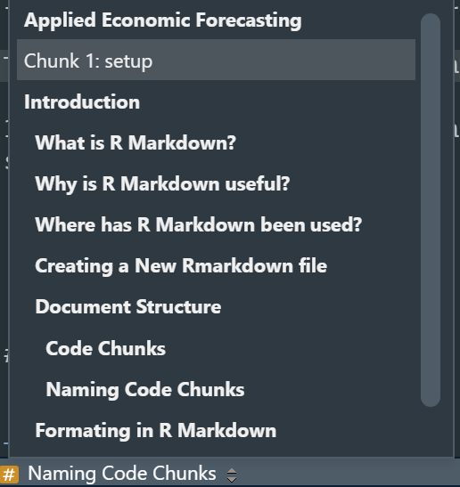

2. Graphics produced by the chunks will have useful names that make them easier to be referenced and hyper-linked further in the document. I utilize this a lot in this class and expect the same of you, especially on your term papers.
3. You can set up networks of cached chunks to avoid re-performing expensive computations on every run.

*NOTE: The code chunk name `setup` is usually reserved for defining global options (more detail below) and libraries.*

### 1.3.3 Chunk Options[^1]

Chunk output can be customized with **options**– arguments supplied to chunk header. The instructions range from how large to make our figures, whether to mute the code, output, or both, what title should be applied to tables and graphs, etc. To help make our reports presentable, we will need to change these as we execute our assignments.

`knitr` provides almost 60 options that you can use to customize your code chunks. Here we will cover the most important chunk options that you will use frequently. You can see the full list at http://yihui.name/knitr/options/.

The most important set of options controls whether your code block is executed and what results are inserted in the finished report:

- **`eval = FALSE`**

  prevents code from being evaluated. Of course, if the code is not run, no results will be generated.

  This is useful for displaying example code, or for disabling a large block of code without commenting each line.
- **`include = FALSE`**

  runs the code, but does not show the code or results in the final document.

  Use this for code chunks that you do not want cluttering your report.
- **`echo = FALSE` :**

  prevents code, **but not** the results from appearing in the finished file.

  Use this when writing reports aimed at people who do not need/want to see the underlying R codes.
- **`message = FALSE` or `warning = FALSE`**

  prevents messages or warnings from appearing in the finished file.
- **`results = 'hide'`**

  hides printed output;
- **`fig.show = 'hide'`**

  hides plots.
- **`error = TRUE`**

  causes the render to continue even if code returns an error. This is rarely something you will want to include in the final version of your report, but can be very useful if you need to debug exactly what is going on inside your `.Rmd`.

  It is also useful if you’re teaching R and want to deliberately include an error. **The default, `error = FALSE` causes knitting to fail if there is a single error in the document.**

### 1.3.4 Inline Code

There is one other way to embed R code into an R Markdown document– directly into the text, with `r`. This can be very useful if you are trying to state the result of some value you calculated (in a chunk before) in the text.

For example, suppose that in a chunk above, we calculated the $R^2$ for a regression and stored it into a variable called `r2`.

If, we are trying to interpret the $R^2$ value, instead of manually inserting it in our text, we could type `` ` r round(r2,2)` ``

- This will automatically round `r2` to 2dps and report the value.
- This approach would come in very handy if afterwards you redid your calculations with a longer time period or added another variable. `r2` will change automatically when the associated code chunk is ran and so will the value you reported as $R^2$ in the text.

### 1.3.5 Formating in R Markdown

```
Text formatting
------------------------------------------------------------

*italic*  or _italic_
**bold**   __bold__
`code`
superscript^2^ and subscript~2~

Headings
------------------------------------------------------------

# 1st Level Header

## 2nd Level Header

### 3rd Level Header

Lists
------------------------------------------------------------

*   Bulleted list item 1 (You can use - as well)

*   Item 2

    * Item 2a

    * Item 2b

1.  Numbered list item 1

1.  Item 2. The numbers are incremented automatically in the output.

Links and images
------------------------------------------------------------


[linked phrase](http://example.com)

![optional caption text](path/to/img.png)

Tables
------------------------------------------------------------

First Header  | Second Header
------------- | -------------
Content Cell  | Content Cell
Content Cell  | Content Cell
```

### 1.3.6 Adding Math and Equations

#### 1.3.6.1 General Anatomy of equations

1. A basic **in-line** equation can be added to your R Markdown file by using a pair of `$`.

```r
For example, you could include the mass-energy equation as $E = mc^2$
```

This would then generate an equation that looks like $E = mc^2$.

2. Your equations can also apply in display mode. This is can be achieved by using a two pairs of `$` instead.

```
For example, you could include the mass-energy equation as $$E = mc^2$$
```

This would then generate an equation that looks like
$$E = mc^2$$

**Other quick equation types include:**

1. Fractions:

```
$$\frac{1}{2}$$
```

$$\frac{1}{2}$$
2. Sub(Super) scripts

```
$$y_t = \beta_1 + \beta_2 x_t + \varepsilon_t$$
```

$$y_t = \beta_1 + \beta_2 x_t +
\varepsilon_t$$

```
$$a^2 + b^2 = c^2$$
```

$$a^2 + b^2 = c^2$$

3. Summations

```
$$
\sigma^2 = \sum_{i = 1}^{n}{(\bar{x} - x_i)^2}
$$
```

$$\sigma^2 = \sum_{i = 1}^{n}{(\bar{x} -
x_i)^2}$$

### 1.3.7 .Rmd Scripts (Working Example)

- Open a new rmd file.
- Choose the file type as a pdf.
- Assign the file the name “First R Markdown”, and put your name as the author.
- Click on the `knit` button and witness the magic.
- Now delete all texts after line 11
- Insert a new code chunk
  - recall that you can achieve this using `CTRL + ALT + I` or by clicking on *Insert* then R.
- In your setup chunk, call the `fpp3` package
- Now add some code and equations to your `.Rmd` document.
[^1]: credit: https://r4ds.had.co.nz/r-markdown.html